# Kidney transplantation vs dialysis among elderly people:Markov based analysis

### 10.2.3 One-way sensitivity table and threshold analysis (addition)

Here we wanted tro find out, how far would each input have to move before the decision flips to dialysis.

```r
n_wtp_thr <- 50000   # $ per QALY

# Readable labels for tables and plots
v_par_labels <- c(
  r_dial_exc             = "Extra death rate on dialysis (/year)",
  hr_early               = "HR of death, graft months 1-3 vs dialysis",
  r_GL_y1                = "Graft-loss rate, months 1-12 (/year)",
  r_G_exc                = "Extra death rate with a graft, month 4+ (/year)",
  r_GL_y2p               = "Graft-loss rate, month 13+ (/year)",
  p_GL_dead_annual       = "Death in first year after graft loss",
  u_dial                 = "Utility, dialysis",
  early_utility_fraction = "Utility gain in graft months 1-3 (fraction)",
  u_graft                = "Utility, functioning graft",
  c_dial                 = "Cost of dialysis (/month)",
  c_G1to3                = "Cost, graft months 1-3 (/month)",
  c_G4to12               = "Cost, graft months 4-12 (/month)",
  c_G13p                 = "Cost, graft month 13+ (/month)",
  c_tx_once              = "Cost of transplant (one-time)",
  d_c                    = "Discount rate, costs",
  d_e                    = "Discount rate, QALYs",
  n_cycles               = "Time horizon (months)")

# Incremental NMB (transplant - dialysis) with ONE parameter changed
f_inc_nmb <- function(par, val) {
  l <- l_params_all
  l[[par]] <- val
  ce <- calculate_ce_out(l, n_wtp = n_wtp_thr)
  ce$NMB[2] - ce$NMB[1]
}

# Values each parameter can logically take (where the threshold is searched)
f_domain <- function(par, base) {
  if (grepl("^c_", par))                                  return(c(0, 50 * base))
  if (grepl("^u_|^p_|^early_utility_fraction$", par))     return(c(1e-6, 1 - 1e-6))
  if (grepl("^r_", par))                                  return(c(1e-6, 2))
  if (par == "hr_early")                                  return(c(0.05, 20))
  if (par %in% c("d_c", "d_e"))                           return(c(0, 0.10))
  stop("No search domain for ", par)
}

# Threshold: evaluate on a grid of 25 values, find where the sign changes,
# then solve exactly with uniroot(). NA = the decision never changes.
f_threshold <- function(par) {
  base <- l_params_all[[par]]
  dom  <- f_domain(par, base)
  v_x  <- seq(dom[1], dom[2], length.out = 25)
  v_y  <- vapply(v_x, function(x) f_inc_nmb(par, x), numeric(1))
  k    <- which(diff(sign(v_y)) != 0)
  if (length(k) == 0) return(c(threshold = NA, dom_lo = dom[1], dom_hi = dom[2]))
  k    <- k[which.min(abs(v_x[k] - base))]          # crossing closest to the base case
  root <- uniroot(function(x) f_inc_nmb(par, x), lower = v_x[k], upper = v_x[k + 1],
                  tol = 1e-6 * max(1, abs(base)))$root
  c(threshold = root, dom_lo = dom[1], dom_hi = dom[2])
}

v_pars_thr <- setdiff(df_owsa_lit$pars, "n_cycles")   # horizon handled below
m_thr <- t(vapply(v_pars_thr, f_threshold, numeric(3)))

df_thr <- data.frame(
  pars        = v_pars_thr,
  Parameter   = unname(v_par_labels[v_pars_thr]),
  Base        = df_owsa_lit$base[match(v_pars_thr, df_owsa_lit$pars)],
  Range_low   = df_owsa_lit$min [match(v_pars_thr, df_owsa_lit$pars)],
  Range_high  = df_owsa_lit$max [match(v_pars_thr, df_owsa_lit$pars)],
  IncNMB_low  = df_tornado$low  [match(v_pars_thr, as.character(df_tornado$parameter))],
  IncNMB_high = df_tornado$high [match(v_pars_thr, as.character(df_tornado$parameter))],
  Threshold   = m_thr[, "threshold"],
  Dom_low     = m_thr[, "dom_lo"],
  Dom_high    = m_thr[, "dom_hi"])

# Time horizon: shortest horizon (even months) from which transplant stays cost-effective
v_h     <- seq(2, 60, by = 2)
v_h_nmb <- vapply(v_h, function(h) f_inc_nmb("n_cycles", h), numeric(1))
n_breakeven_h <- if (all(v_h_nmb > 0)) 2 else v_h[max(which(v_h_nmb <= 0)) + 1]
n_breakeven_h        # expected about 20 months (incremental NMB < 0 at 18, > 0 at 20)
```

```
## [1] 20
```

```r
df_thr <- rbind(df_thr, data.frame(
  pars = "n_cycles", Parameter = v_par_labels[["n_cycles"]], Base = n_cycles,
  Range_low = 60, Range_high = n_cycles,
  IncNMB_low  = df_tornado$low [as.character(df_tornado$parameter) == "n_cycles"],
  IncNMB_high = df_tornado$high[as.character(df_tornado$parameter) == "n_cycles"],
  Threshold = n_breakeven_h, Dom_low = 2, Dom_high = n_cycles))

# Formatting
f_fmt <- function(par, x) ifelse(grepl("^c_", par), scales::dollar(round(x)),
                          ifelse(par == "n_cycles", as.character(round(x)), as.character(signif(x, 3))))
df_thr$Within_range <- !is.na(df_thr$Threshold) &
                       df_thr$Threshold >= df_thr$Range_low & df_thr$Threshold <= df_thr$Range_high
df_thr$Dialysis_preferred_if <- ifelse(
  is.na(df_thr$Threshold),
  paste0("Never (searched ", f_fmt(df_thr$pars, df_thr$Dom_low), " to ", f_fmt(df_thr$pars, df_thr$Dom_high), ")"),
  ifelse(df_thr$Threshold < df_thr$Base,
         paste0("< ", f_fmt(df_thr$pars, df_thr$Threshold)),
         paste0("> ", f_fmt(df_thr$pars, df_thr$Threshold))))

df_thr_table <- data.frame(
  Parameter                   = df_thr$Parameter,
  `Base case`                 = f_fmt(df_thr$pars, df_thr$Base),
  `Range`                     = paste0(f_fmt(df_thr$pars, df_thr$Range_low), " - ", f_fmt(df_thr$pars, df_thr$Range_high)),
  `Inc. NMB at low`           = scales::dollar(round(df_thr$IncNMB_low)),
  `Inc. NMB at high`          = scales::dollar(round(df_thr$IncNMB_high)),
  check.names = FALSE)
knitr::kable(df_thr_table, align = "lllrr",
             caption = paste0("One-way sensitivity analysis and threshold values (WTP $",
                              scales::comma(n_wtp_thr), "/QALY; base-case incremental NMB ",
                              scales::dollar(round(n_inc_nmb_base)), ")"))
```

| Parameter | Base case | Range | Inc. NMB at low | Inc. NMB at high |
| --- | --- | --- | --- | --- |
| Extra death rate on dialysis (/year) | 0.0892 | 0.0892 - 0.0929 | $315,626 | $307,432 |
| Extra death rate with a graft, month 4+ (/year) | 0.0419 | 0.0169 - 0.0748 | $309,749 | $321,714 |
| HR of death, graft months 1-3 vs dialysis | 3 | 1.5 - 3.49 | $312,441 | $316,639 |
| Graft-loss rate, months 1-12 (/year) | 0.0694 | 0.046 - 0.103 | $319,979 | $309,492 |
| Graft-loss rate, month 13+ (/year) | 0.0373 | 0.0119 - 0.0373 | $346,504 | $315,626 |
| Death in first year after graft loss | 0.502 | 0.474 - 0.533 | $312,565 | $319,023 |
| Utility, dialysis | 0.71 | 0.67 - 0.74 | $326,476 | $307,489 |
| Utility, functioning graft | 0.82 | 0.74 - 0.9 | $291,475 | $339,776 |
| Cost of dialysis (/month) | $8,929 | $6,786 - $9,087 | $171,383 | $326,267 |
| Cost, graft months 1-3 (/month) | $14,133 | $13,336 - $14,931 | $317,395 | $313,856 |
| Cost, graft months 4-12 (/month) | $4,748 | $4,480 - $5,016 | $317,612 | $313,639 |
| Cost, graft month 13+ (/month) | $3,272 | $3,087 - $3,457 | $327,633 | $303,617 |
| Cost of transplant (one-time) | $61,042 | $57,598 - $64,486 | $319,070 | $312,181 |
| Discount rate, costs | 0.015 | 0 - 0.03 | $340,727 | $293,280 |
| Discount rate, QALYs | 0.015 | 0 - 0.03 | $323,260 | $309,248 |
| Utility gain in graft months 1-3 (fraction) | 0 | 0 - 1 | $315,626 | $316,643 |
| Time horizon (months) | 420 | 60 - 420 | $150,926 | $315,626 |

```r
# Expected thresholds: dialysis < $4,240/month; graft month 13+ > $8,125/month;
# graft months 4-12 > $47,314; graft months 1-3 > $156,375; transplant > $376,668;
# extra death rate on dialysis > 0.670/year (about 3% alive at 5 years on dialysis);
# horizon < 20 months. No other clinical parameter or utility changes the decision.
```

```r
df_thr_table <- data.frame(
  Input       = df_thr$Parameter,
  `Base case` = f_fmt(df_thr$pars, df_thr$Base),
  Range       = paste0(f_fmt(df_thr$pars, df_thr$Range_low), " - ", f_fmt(df_thr$pars, df_thr$Range_high)),
  Threshold   = ifelse(is.na(df_thr$Threshold),
                       "-",
                       ifelse(df_thr$Threshold < df_thr$Base,
                              paste0("< ", f_fmt(df_thr$pars, df_thr$Threshold)),
                              paste0("> ", f_fmt(df_thr$pars, df_thr$Threshold)))),
  check.names = FALSE)

knitr::kable(df_thr_table, align = "llll",
             caption = paste0("One-way sensitivity analysis: base case, literature range and threshold at which ",
                              "continued dialysis becomes preferred (WTP $", scales::comma(n_wtp_thr),
                              "/QALY; base-case incremental NMB ", scales::dollar(round(n_inc_nmb_base)), ")"))
```

One-way sensitivity analysis: base case, literature range and threshold at which continued dialysis becomes preferred (WTP $50,000/QALY; base-case incremental NMB $315,626)

| Input | Base case | Range | Threshold |
| --- | --- | --- | --- |
| Extra death rate on dialysis (/year) | 0.0892 | 0.0892 - 0.0929 | > 0.67 |
| Extra death rate with a graft, month 4+ (/year) | 0.0419 | 0.0169 - 0.0748 | - |
| HR of death, graft months 1-3 vs dialysis | 3 | 1.5 - 3.49 | - |
| Graft-loss rate, months 1-12 (/year) | 0.0694 | 0.046 - 0.103 | - |
| Graft-loss rate, month 13+ (/year) | 0.0373 | 0.0119 - 0.0373 | - |
| Death in first year after graft loss | 0.502 | 0.474 - 0.533 | - |
| Utility, dialysis | 0.71 | 0.67 - 0.74 | - |
| Utility, functioning graft | 0.82 | 0.74 - 0.9 | - |
| Cost of dialysis (/month) | $8,929 | $6,786 - $9,087 | < $4,240 |
| Cost, graft months 1-3 (/month) | $14,133 | $13,336 - $14,931 | > $156,375 |
| Cost, graft months 4-12 (/month) | $4,748 | $4,480 - $5,016 | > $47,314 |
| Cost, graft month 13+ (/month) | $3,272 | $3,087 - $3,457 | > $8,125 |
| Cost of transplant (one-time) | $61,042 | $57,598 - $64,486 | > $376,668 |
| Discount rate, costs | 0.015 | 0 - 0.03 | - |
| Discount rate, QALYs | 0.015 | 0 - 0.03 | - |
| Utility gain in graft months 1-3 (fraction) | 0 | 0 - 1 | - |
| Time horizon (months) | 420 | 60 - 420 | < 20 |

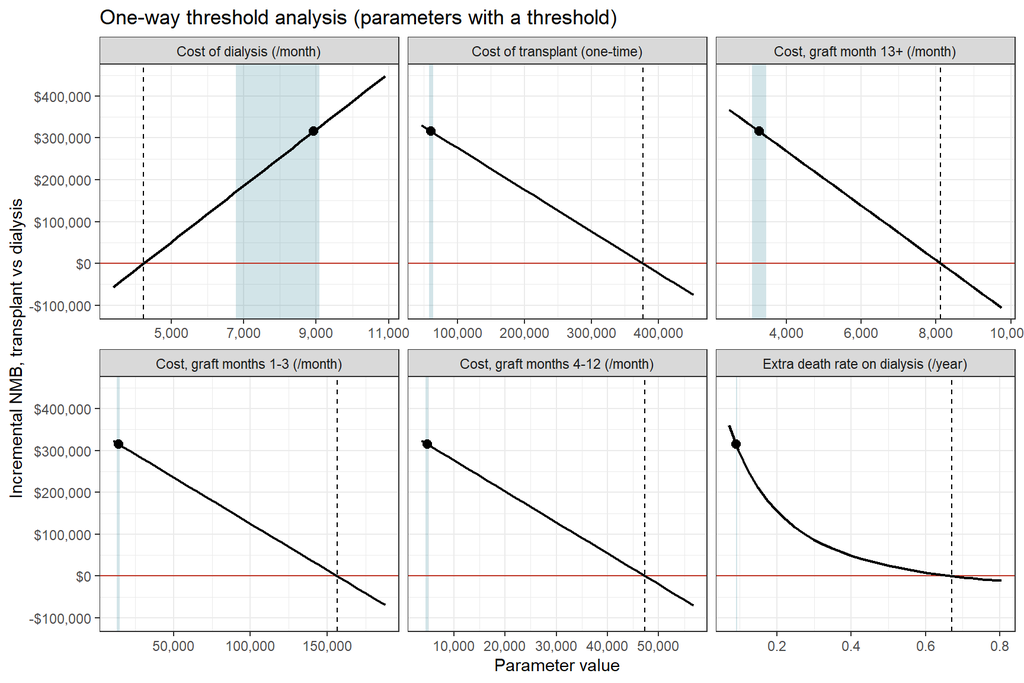

```r
## Plot 2: one-way curves for the parameters that have a threshold
# (as in the lecture, slide 60): incremental NMB across values of the
# parameter; shaded = literature range; red line = 0 (decision changes);
# dashed line = threshold; dot = base case.
df_thr_yes <- subset(df_thr, !is.na(Threshold) & pars != "n_cycles")
if (nrow(df_thr_yes) > 0) {
  df_curves <- do.call(rbind, lapply(df_thr_yes$pars, function(p) {
    r <- df_thr_yes[df_thr_yes$pars == p, ]
    v_x <- seq(0.8 * min(r$Range_low, r$Threshold), 1.2 * max(r$Range_high, r$Threshold), length.out = 30)
    data.frame(Parameter = r$Parameter, x = v_x,
               inc_nmb = vapply(v_x, function(v) f_inc_nmb(p, v), numeric(1)))
  }))
  df_thr_yes$base_nmb <- n_inc_nmb_base
  gg_thr_curves <- ggplot(df_curves, aes(x = x, y = inc_nmb)) +
    geom_rect(data = df_thr_yes, inherit.aes = FALSE,
              aes(xmin = Range_low, xmax = Range_high, ymin = -Inf, ymax = Inf),
              fill = "#1F7A8C", alpha = 0.2) +
    geom_hline(yintercept = 0, colour = "#C0392B") +
    geom_line(linewidth = 0.8) +
    geom_vline(data = df_thr_yes, aes(xintercept = Threshold), linetype = "dashed") +
    geom_point(data = df_thr_yes, aes(x = Base, y = base_nmb), size = 2.5) +
    facet_wrap(~ Parameter, scales = "free_x") +
    scale_x_continuous(labels = function(x) format(x, big.mark = ",", scientific = FALSE, trim = TRUE)) +   # costs and rates share this axis style
    scale_y_continuous(labels = scales::dollar) +
    labs(x = "Parameter value", y = "Incremental NMB, transplant vs dialysis",
         title = "One-way threshold analysis (parameters with a threshold)") +
    theme_bw(base_size = 11)
  gg_thr_curves
}
```

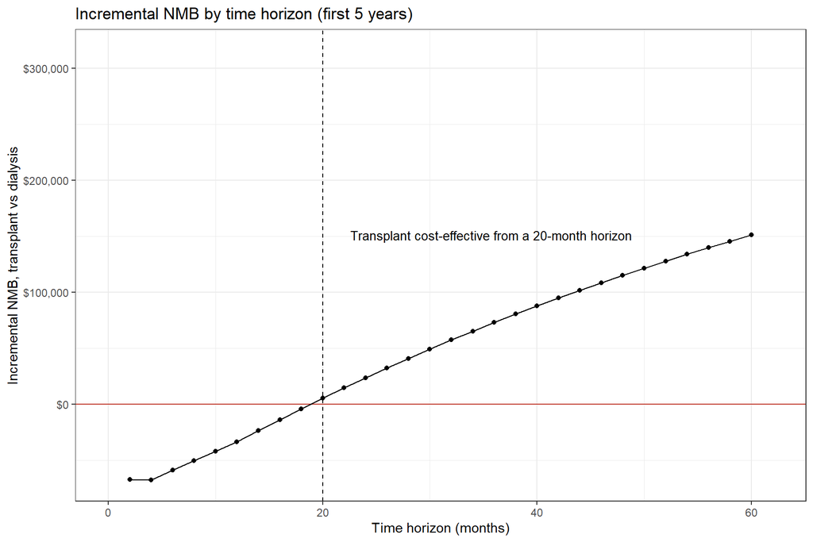

```r
## Plot 3: time horizon
gg_thr_h <- ggplot(data.frame(h = c(v_h, n_cycles), nmb = c(v_h_nmb, n_inc_nmb_base)), aes(h, nmb)) +
  geom_hline(yintercept = 0, colour = "#C0392B") +
  geom_line() + geom_point(size = 1.5) +
  geom_vline(xintercept = n_breakeven_h, linetype = "dashed") +
  annotate("text", x = n_breakeven_h, y = max(v_h_nmb), hjust = -0.1, size = 3.5,
           label = paste0("Transplant cost-effective from a ", n_breakeven_h, "-month horizon")) +
  scale_x_continuous(limits = c(0, 62)) +
  scale_y_continuous(labels = scales::dollar) +
  labs(x = "Time horizon (months)", y = "Incremental NMB, transplant vs dialysis",
       title = "Incremental NMB by time horizon (first 5 years)") +
  theme_bw(base_size = 11)
gg_thr_h
```

## 10.3 Two-way sensitivity analysis (TWSA)

Dialysis cost per month vs graft follow-up cost per month (month 13+).

```r
## Fixed colours and labels for all two-way plots
v_twsa_fill <- c("Continued.dialysis" = "#6C5B7B",
                 "ECD.DCD.transplant" = "#1F7A8C")
v_twsa_lab  <- c("Continued.dialysis" = "Continued dialysis",
                 "ECD.DCD.transplant" = "ECD/DCD transplant")
```

```r
# Row 1 = x-axis (c_dial), row 2 = y-axis (c_G13p); literature ranges from section 10.2
df_params_twsa <- df_params_owsa[df_params_owsa$pars %in% c("c_dial", "c_G13p"), ]

twsa_nmb <- run_twsa_det(params_range    = df_params_twsa,
                         params_basecase = l_params_all,
                         nsamp           = 40,
                         FUN             = calculate_ce_out,
                         outcomes        = "NMB",
                         strategies      = v_names_str,
                         n_wtp           = 50000)
```

### 10.3.1 Plot TWSA

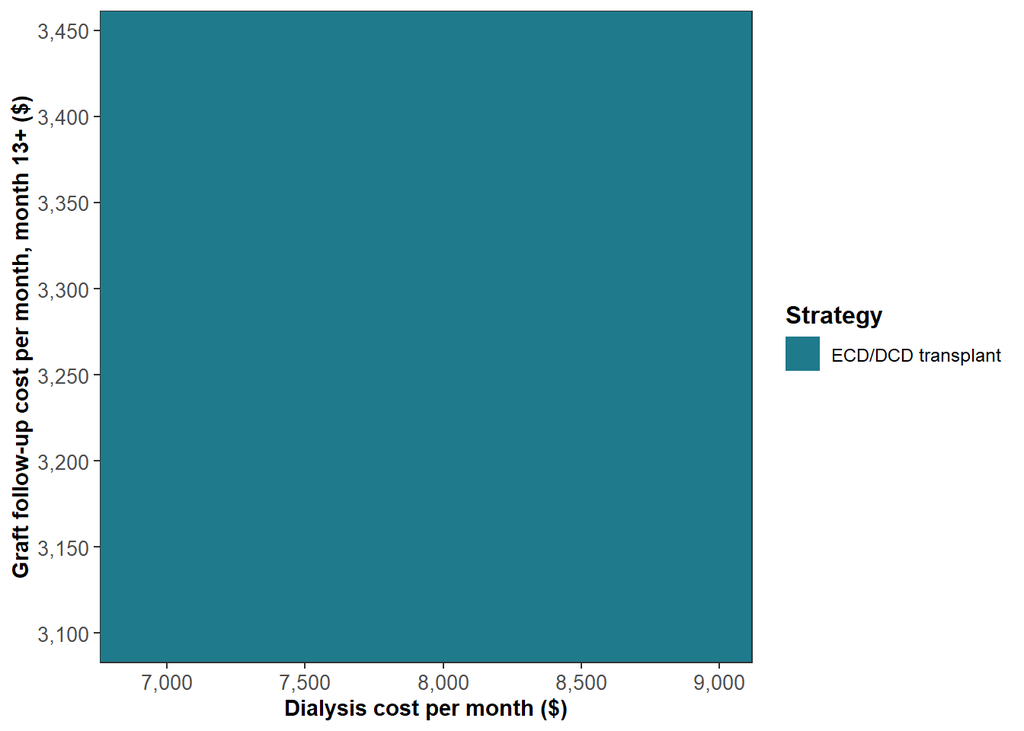

```r
plot(twsa_nmb) +
  scale_fill_manual(values = v_twsa_fill, labels = v_twsa_lab, drop = FALSE) +
  labs(x = "Dialysis cost per month ($)",
       y = "Graft follow-up cost per month, month 13+ ($)",
       fill = "Strategy")
```

```r
# One colour expected: transplant optimal across the literature ranges.
```

### 10.3.2 TWSA with wider ranges to show the threshold

```r
# Break-even: dialysis about $4,240/month at base graft cost ($3,272);
# graft cost about $8,125/month at base dialysis cost ($8,929).
df_params_twsa_wide <- data.frame(pars = c("c_dial", "c_G13p"),
                                  min  = c(2000,     1500),
                                  max  = c(12500,    9000))
twsa_nmb_wide <- run_twsa_det(params_range    = df_params_twsa_wide,
                              params_basecase = l_params_all,
                              nsamp           = 40,
                              FUN             = calculate_ce_out,
                              outcomes        = "NMB",
                              strategies      = v_names_str,
                              n_wtp           = 50000)
```

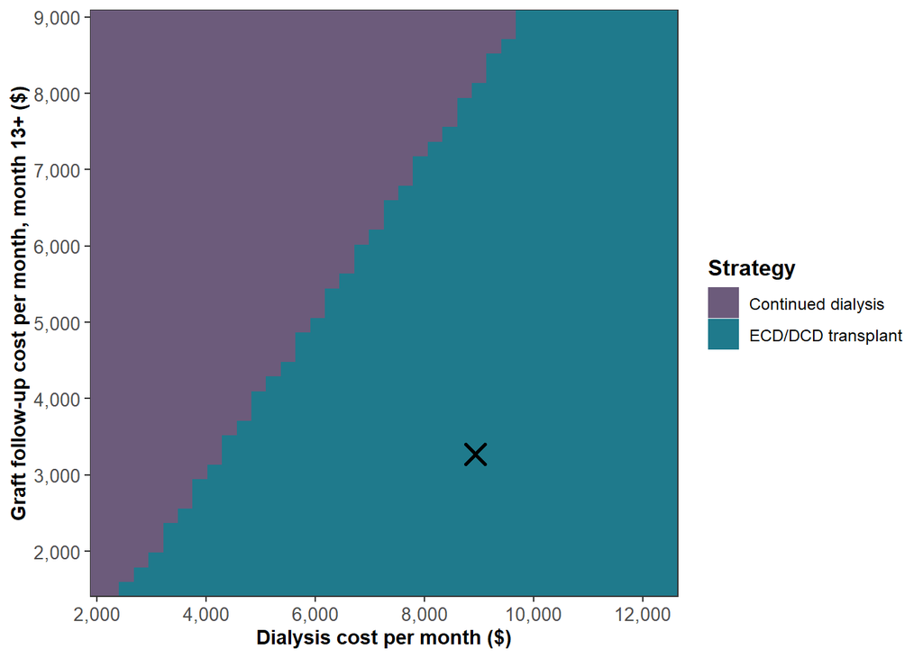

```r
plot(twsa_nmb_wide) +
  scale_fill_manual(values = v_twsa_fill, labels = v_twsa_lab, drop = FALSE) +
  labs(x = "Dialysis cost per month ($)",
       y = "Graft follow-up cost per month, month 13+ ($)",
       fill = "Strategy") +
  annotate("point", x = l_params_all$c_dial, y = l_params_all$c_G13p,
           shape = 4, size = 4, stroke = 1.5)   # base case
```

# **11 Probabilistic Sensitivity Analysis (PSA)**

## 11.1 Model input

Here we used SE from CI or 10% of mean base values to calculate scale and shape for PSA. Beta distribution was used to make values between 0 and 1. Gamma distirbution was used for parameters that can take values from 0 to infinity.

```r
# Store the parameter names into a vector
v_names_params <- names(l_params_all)

## Test functions to generate CE outcomes and PSA dataset
# Test function to compute CE outcomes
calculate_ce_out(l_params_all)
```

```
##             Strategy     Cost   Effect       NMB
## 1 Continued dialysis 694883.5 4.604556 -464655.7
## 2 ECD/DCD transplant 434218.7 5.703778 -149029.8
```

```r
# PSA distributions, standard errors and their basis (method of moments)
options(knitr.kable.NA = "-")

knitr::kable(get_sa_spec(l_params_all)[, c("pars", "mean", "se", "distribution", "shape", "scale", "alpha", "beta", "basis")],
             digits = 5, caption = "PSA distributions")
```

PSA distributions

| pars | mean | se | distribution | shape | scale | alpha | beta | basis |
| --- | --- | --- | --- | --- | --- | --- | --- | --- |
| r_dial_exc | 0.08924 | 0.00094 | gamma | 9086.21638 | 0.00001 | - | - | SE from 95% CI of 5-y dialysis survival 54-55% [1], as rates |
| hr_early | 3.00000 | 0.50765 | gamma | 34.92275 | 0.08590 | - | - | SE from 95% CI of HR 2.29 (1.50-3.49) [2] |
| r_GL_y1 | 0.06935 | 0.00694 | gamma | 100.00000 | 0.00069 | - | - | Range across studies: assumed SE = 10% of mean |
| r_GL_y2p | 0.03726 | 0.00373 | gamma | 100.00000 | 0.00037 | - | - | Range across studies: assumed SE = 10% of mean |
| r_G_exc | 0.04194 | 0.01477 | gamma | 8.06332 | 0.00520 | - | - | SE from 95% CI of 5-y transplant survival 51-66% [1], as rates |
| p_GL_dead_annual | 0.50200 | 0.01505 | beta | - | - | 553.49178 | 549.08149 | SE from 95% CI 0.474-0.533 [4] |
| c_dial | 8928.97000 | 892.89700 | gamma | 100.00000 | 89.28970 | - | - | Range across studies: assumed SE = 10% of mean |
| c_G1to3 | 14133.18000 | 406.88447 | gamma | 1206.52838 | 11.71392 | - | - | SE from 95% CI of 2-y transplant cost $114,287-$127,956 [6] (SE 2.88% of mean) |
| c_G4to12 | 4747.60000 | 136.68012 | gamma | 1206.52838 | 3.93493 | - | - | SE from 95% CI of 2-y transplant cost $114,287-$127,956 [6] (SE 2.88% of mean) |
| c_G13p | 3272.01000 | 94.19890 | gamma | 1206.52838 | 2.71192 | - | - | SE from 95% CI of 2-y transplant cost $114,287-$127,956 [6] (SE 2.88% of mean) |
| c_tx_once | 61041.80000 | 1757.35119 | gamma | 1206.52838 | 50.59293 | - | - | SE from 95% CI of 2-y transplant cost $114,287-$127,956 [6] (SE 2.88% of mean) |
| u_dial | 0.71000 | 0.01786 | beta | - | - | 457.73870 | 186.96370 | SE from 95% CI of dialysis decrement 0.08-0.15 [8] |
| u_graft | 0.82000 | 0.04082 | beta | - | - | 71.82946 | 15.76744 | SE from 95% CI 0.74-0.90 [8] |

```r
# Test function to generate PSA input dataset
generate_psa_params(n_sim = 10)
```

```
##    r_dial_exc hr_early    r_GL_y1   r_GL_y2p    r_G_exc p_GL_dead_annual
## 1  0.09054669 2.923334 0.07643886 0.04051945 0.02166770        0.5109573
## 2  0.08927648 2.498177 0.06283075 0.03501084 0.02576638        0.5091219
## 3  0.08839385 3.008104 0.07117632 0.03718425 0.05367931        0.4825872
## 4  0.08826739 3.044352 0.07249766 0.03432325 0.06252896        0.4925421
## 5  0.08899835 2.429594 0.07855719 0.03009442 0.06403179        0.5269322
## 6  0.08912841 4.455750 0.06851245 0.03280637 0.02913823        0.5230074
## 7  0.08860839 2.860050 0.07003205 0.03491820 0.04025750        0.5270641
## 8  0.09077493 3.146796 0.06479299 0.04238009 0.03947647        0.4903123
## 9  0.08782087 2.883448 0.07726216 0.03501624 0.03376308        0.5258452
## 10 0.08727743 3.422098 0.06344376 0.03574321 0.03869649        0.5096487
##       c_dial  c_G1to3 c_G4to12   c_G13p c_tx_once    u_dial   u_graft
## 1   9520.734 15011.96 4776.308 3152.296  64762.01 0.7080918 0.8558456
## 2   9434.448 13977.71 4620.940 3403.466  59677.95 0.6765481 0.7522569
## 3   9478.380 14021.51 4885.487 3290.041  62235.92 0.7054883 0.8601759
## 4  10656.841 14804.94 4804.015 3364.950  62291.61 0.7521380 0.8178673
## 5   7144.206 14408.69 4927.718 3206.354  62812.75 0.6743920 0.7438284
## 6   8556.038 14260.65 4864.225 3232.385  62192.09 0.7323395 0.8099653
## 7   8828.670 14260.99 4935.243 3478.548  63005.48 0.7132200 0.8539144
## 8   7972.900 14291.17 4764.864 3287.722  62470.92 0.6936629 0.8152056
## 9   8270.820 14386.52 4760.298 3195.526  59789.91 0.6868370 0.8027356
## 10  7295.315 14300.58 4729.850 3245.005  59038.26 0.7158069 0.8339262
```

```r
## Generate PSA dataset
# Number of simulations
n_sim <- 1000

# Generate PSA input dataset
df_psa_input <- generate_psa_params(n_sim = n_sim, params_basecase = l_params_all)
# First six observations
head(df_psa_input)
```

```
##   r_dial_exc hr_early    r_GL_y1   r_GL_y2p    r_G_exc p_GL_dead_annual
## 1 0.09054669 3.625631 0.08014579 0.04152844 0.04072610        0.4942829
## 2 0.08927648 3.235726 0.06380715 0.03665884 0.04361122        0.4935973
## 3 0.08839385 3.176308 0.08040866 0.03343277 0.05054986        0.4837855
## 4 0.08826739 3.347185 0.07524350 0.03304070 0.03572800        0.5020680
## 5 0.08899835 2.898200 0.07806675 0.03977303 0.02693402        0.4954401
## 6 0.08912841 2.763341 0.08178464 0.03920109 0.04568355        0.5183476
##      c_dial  c_G1to3 c_G4to12   c_G13p c_tx_once    u_dial   u_graft
## 1  9578.567 13784.77 4950.405 3245.340  61374.26 0.7531642 0.8281145
## 2  9945.746 14535.29 4706.415 3061.583  61246.24 0.7317203 0.9057641
## 3 10345.275 14633.97 4559.193 3418.412  61315.73 0.7176092 0.7767985
## 4  8396.117 14074.98 5164.658 3344.749  59068.77 0.7122739 0.8525483
## 5  7854.395 13872.92 4709.368 3280.091  61400.04 0.7288916 0.7537798
## 6 10350.376 14379.87 4850.377 3358.707  62698.90 0.7072975 0.8062584
```

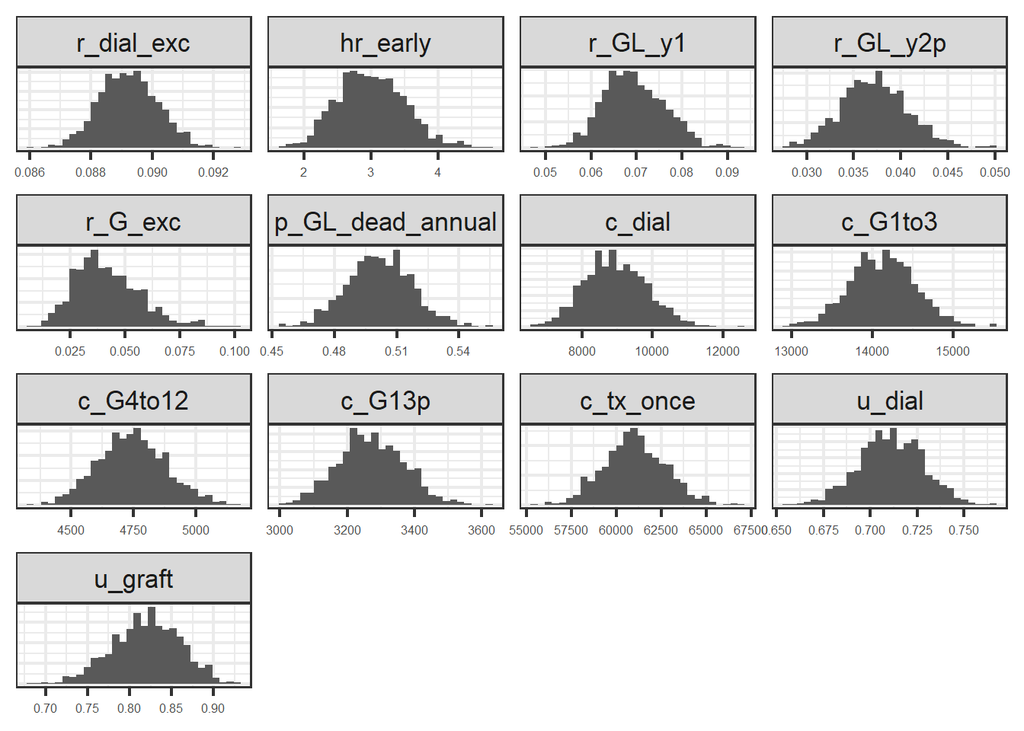

```r
### Histogram of parameters
ggplot(melt(df_psa_input, variable.name = "Parameter"), aes(x = value)) +
  facet_wrap(~Parameter, scales = "free") +
  geom_histogram(aes(y = after_stat(density))) +
  ylab("") +
  theme_bw(base_size = 16) +
  theme(axis.text = element_text(size = 6),
        axis.title.x = element_blank(),
        axis.title.y = element_blank(),
        axis.text.y  = element_blank(),
        axis.ticks.y = element_blank())
```

## 11.2 Run PSA

```r
# Initialize data.frames with PSA output
# data.frame of costs
df_c <- as.data.frame(matrix(0,
                             nrow = n_sim,
                             ncol = n_str))
colnames(df_c) <- v_names_str
# data.frame of effectiveness
df_e <- as.data.frame(matrix(0,
                             nrow = n_sim,
                             ncol = n_str))
colnames(df_e) <- v_names_str

# Conduct probabilistic sensitivity analysis
# Run Markov model on each parameter set of PSA input dataset
n_time_init_psa_series <- Sys.time()
for (i in 1:n_sim) { # i <- 1
  l_psa_input <- update_param_list(l_params_all, as.list(df_psa_input[i,]))
  # Outcomes
  l_out_ce_temp  <- calculate_ce_out(l_psa_input)
  df_c[i, ]  <- l_out_ce_temp$Cost
  df_e[i, ]  <- l_out_ce_temp$Effect
  # Display simulation progress
  if (i/(n_sim/100) == round(i/(n_sim/100), 0)) { # display progress every 5%
    cat('\r', paste(i/n_sim * 100, "% done", sep = " "))
  }
}
```

[output not shown]

```r
n_time_end_psa_series <- Sys.time()
n_time_total_psa_series <- n_time_end_psa_series - n_time_init_psa_series
print(paste0("PSA with ", scales::comma(n_sim), " simulations run in series in ",
             round(n_time_total_psa_series, 2), " ",
             units(n_time_total_psa_series)))
```

```
## [1] "PSA with 1,000 simulations run in series in 51.21 secs"
```

# 11.3 Visualize PSA results for CEA

```r
### Create PSA object
l_psa <- make_psa_obj(cost          = df_c,
                      effectiveness = df_e,
                      parameters    = df_psa_input,
                      strategies    = v_names_str)
l_psa$strategies <- v_names_str
colnames(l_psa$effectiveness) <- v_names_str
colnames(l_psa$cost) <- v_names_str

# Vector with willingness-to-pay (WTP) thresholds.
v_wtp <- seq(0, 150000, by = 5000)
```

## 11.3.1 Cost-Effectiveness Scatter plot

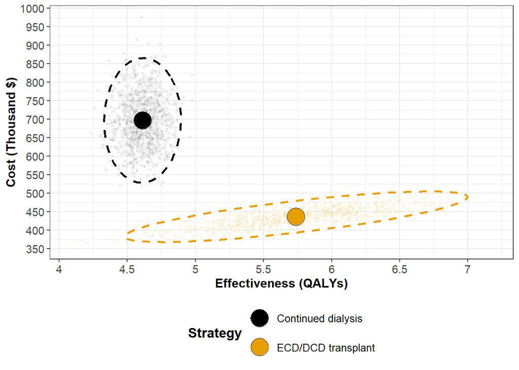

```r
### Cost-Effectiveness Scatter plot
txtsize <- 13
gg_scattter <- plot_psa(l_psa, txtsize = txtsize) +
  ggthemes::scale_color_colorblind() +
  ggthemes::scale_fill_colorblind() +
  scale_y_continuous("Cost (Thousand $)",
                     breaks = number_ticks(10),
                     labels = function(x) x/1000) +
  xlab("Effectiveness (QALYs)") +
  guides(col = guide_legend(nrow = 2)) +
  theme(legend.position = "bottom")
gg_scattter
```

### 11.3.1b Incremental cost-effectiveness plane with WTP line (addition)

```r
# plot_psa() above shows ABSOLUTE costs and QALYs of each strategy, so a
# willingness-to-pay line cannot be drawn on it. Here each PSA draw is one
# point: transplant minus dialysis.
n_wtp_plane <- 50000                                    # $ per QALY
df_inc_psa <- data.frame(inc_qaly = df_e[[v_names_str[2]]] - df_e[[v_names_str[1]]],
                         inc_cost = df_c[[v_names_str[2]]] - df_c[[v_names_str[1]]])
# Cost-effective at the threshold = point lies below the WTP line
# (inc_cost < WTP x inc_qaly), i.e. incremental NMB > 0
df_inc_psa$cost_effective <- df_inc_psa$inc_cost < n_wtp_plane * df_inc_psa$inc_qaly

# Share of draws in each quadrant and below the line
v_share <- c(
  cost_effective_at_WTP = mean(df_inc_psa$cost_effective),
  dominant              = mean(df_inc_psa$inc_cost < 0 & df_inc_psa$inc_qaly > 0),  # cheaper and better (SE quadrant)
  more_costly_better    = mean(df_inc_psa$inc_cost > 0 & df_inc_psa$inc_qaly > 0),  # NE quadrant
  cheaper_worse         = mean(df_inc_psa$inc_cost < 0 & df_inc_psa$inc_qaly < 0),  # SW quadrant
  dominated             = mean(df_inc_psa$inc_cost > 0 & df_inc_psa$inc_qaly < 0))  # NW quadrant
round(v_share, 3)
```

```
## cost_effective_at_WTP              dominant    more_costly_better
##                 1.000                 0.976                 0.000
##         cheaper_worse             dominated
##                 0.024                 0.000
```

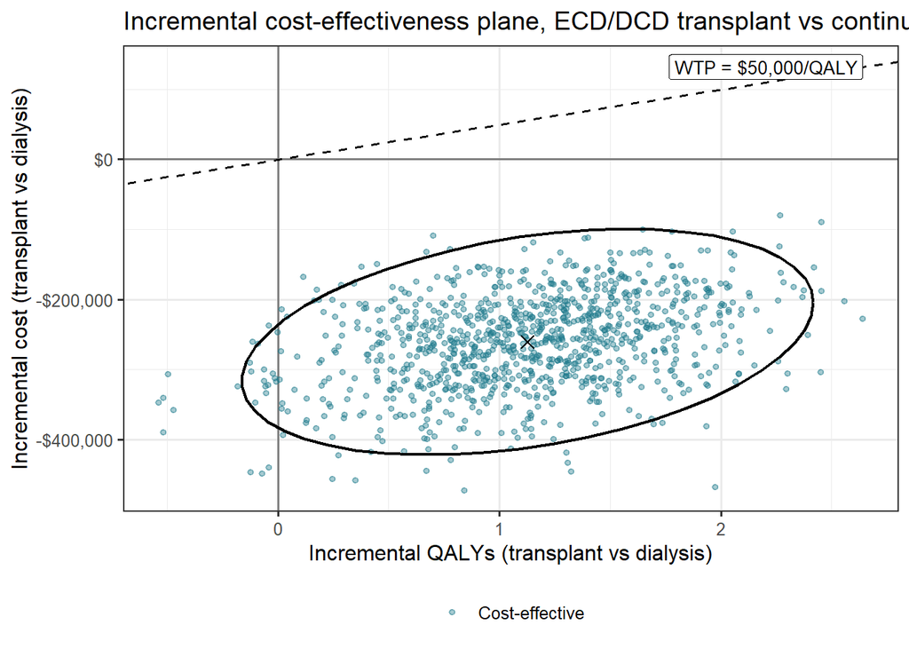

```r
gg_plane <- ggplot(df_inc_psa, aes(x = inc_qaly, y = inc_cost)) +
  geom_hline(yintercept = 0, colour = "grey50") +
  geom_vline(xintercept = 0, colour = "grey50") +
  geom_point(aes(colour = cost_effective), alpha = 0.4, size = 1.2) +
  stat_ellipse(level = 0.95, type = "norm", linewidth = 0.8) +    # 95% confidence ellipse
  geom_point(aes(x = mean(inc_qaly), y = mean(inc_cost)), size = 3, shape = 4) +  # mean
  geom_abline(intercept = 0, slope = n_wtp_plane, linetype = "dashed") +           # WTP line
  annotate("label", x = max(df_inc_psa$inc_qaly), y = n_wtp_plane * max(df_inc_psa$inc_qaly),
           label = "WTP = $50,000/QALY", hjust = 1, size = 3.5) +
  scale_colour_manual(values = c(`TRUE` = "#1F7A8C", `FALSE` = "#E08E0B"),
                      labels = c(`TRUE` = "Cost-effective", `FALSE` = "Not cost-effective"),
                      name = NULL) +
  scale_y_continuous(labels = scales::dollar) +
  labs(x = "Incremental QALYs (transplant vs dialysis)",
       y = "Incremental cost (transplant vs dialysis)",
       title = "Incremental cost-effectiveness plane, ECD/DCD transplant vs continued dialysis") +
  coord_cartesian(ylim = range(c(df_inc_psa$inc_cost, 0, n_wtp_plane * max(df_inc_psa$inc_qaly))),   # include the top of the WTP line so its label shows
                  xlim = range(c(df_inc_psa$inc_qaly, 0))) +
  theme_bw(base_size = 12) +
  theme(legend.position = "bottom")
gg_plane
```

## 11.3.2 Incremental cost-effectiveness ratios (ICERs) with probabilistic output

```r
### Incremental cost-effectiveness ratios (ICERs) with probabilistic output
# Compute expected costs and effects for each strategy from the PSA
df_out_ce_psa <- summary(l_psa)
df_cea_psa <- calculate_icers(cost       = df_out_ce_psa$meanCost,
                              effect     = df_out_ce_psa$meanEffect,
                              strategies = df_out_ce_psa$Strategy)
df_cea_psa
```

```
##             Strategy     Cost   Effect Inc_Cost Inc_Effect ICER Status
## 1 ECD/DCD transplant 436169.5 5.737958       NA         NA   NA     ND
## 2 Continued dialysis 696720.8 4.611145       NA         NA   NA      D
```

## 11.3.3 Plot cost-effectiveness frontier with probabilistic output

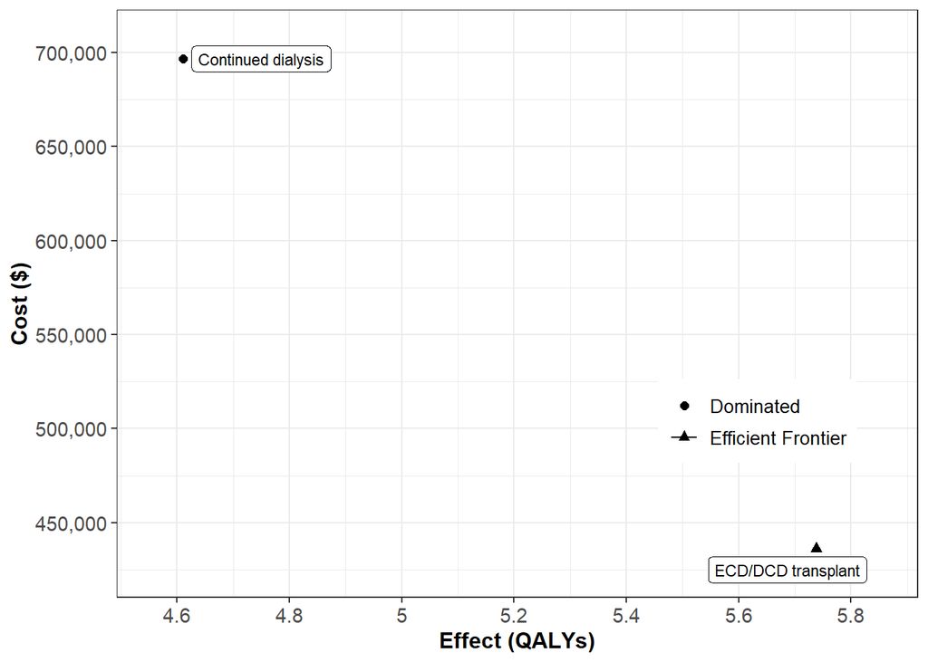

```r
### Plot cost-effectiveness frontier with probabilistic output
plot_icers(df_cea_psa, label = "all", txtsize = txtsize) +
  expand_limits(x = max(table_cea$QALYs) + 0.1) +
  theme(legend.position = c(0.8, 0.3))
```

## 11.3.4 Cost-effectiveness acceptability curves (CEACs) and frontier (CEAF)

```r
### Cost-effectiveness acceptability curves (CEACs) and frontier (CEAF)
ceac_obj <- ceac(wtp = v_wtp, psa = l_psa)
# Regions of highest probability of cost-effectiveness for each strategy
summary(ceac_obj)
```

```
##   range_min range_max     cost_eff_strat
## 1         0    150000 ECD/DCD transplant
```

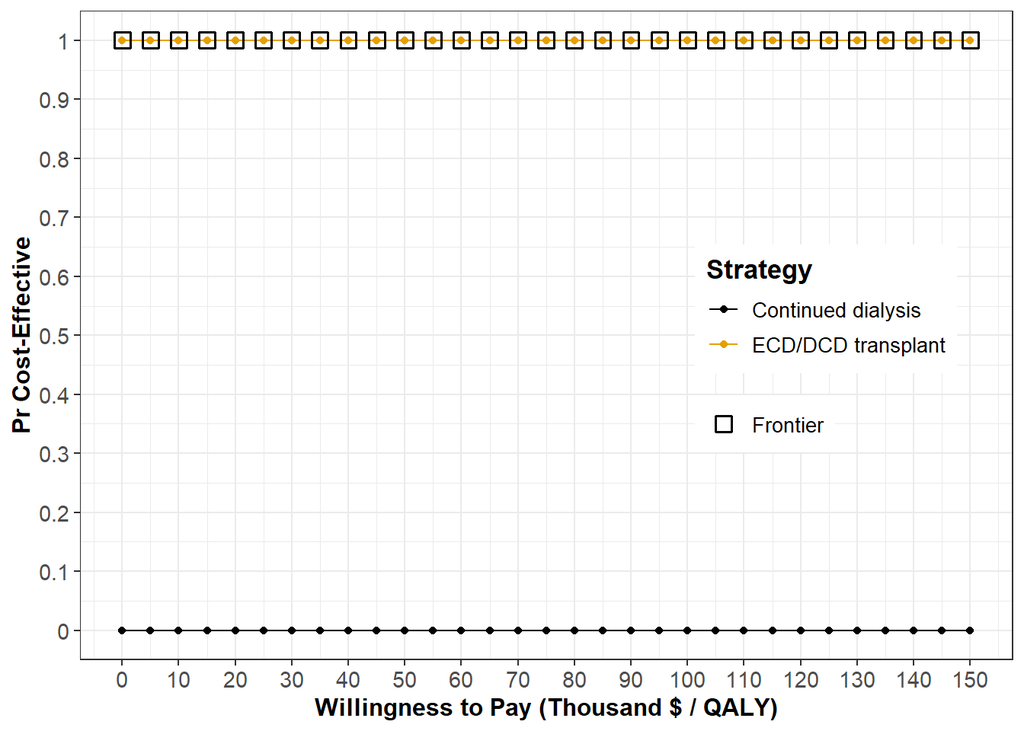

```r
# CEAC & CEAF plot
gg_ceac <- plot_ceac(ceac_obj, txtsize = txtsize, xlim = c(0, NA), n_x_ticks = 14) +
  ggthemes::scale_color_colorblind() +
  ggthemes::scale_fill_colorblind() +
  theme(legend.position = c(0.8, 0.48))
gg_ceac
```

## 11.3.5 Expected Loss Curves (ELCs)

```r
### Expected Loss Curves (ELCs)
elc_obj <- calc_exp_loss(wtp = v_wtp, psa = l_psa)
elc_obj
```

```
##       WTP           Strategy Expected_Loss On_Frontier
## 1       0 Continued dialysis      260551.3       FALSE
## 2       0 ECD/DCD transplant           0.0        TRUE
## 3    5000 Continued dialysis      266185.3       FALSE
## 4    5000 ECD/DCD transplant           0.0        TRUE
## 5   10000 Continued dialysis      271819.4       FALSE
## 6   10000 ECD/DCD transplant           0.0        TRUE
## 7   15000 Continued dialysis      277453.5       FALSE
## 8   15000 ECD/DCD transplant           0.0        TRUE
## 9   20000 Continued dialysis      283087.5       FALSE
## 10  20000 ECD/DCD transplant           0.0        TRUE
## 11  25000 Continued dialysis      288721.6       FALSE
## 12  25000 ECD/DCD transplant           0.0        TRUE
## 13  30000 Continued dialysis      294355.7       FALSE
## 14  30000 ECD/DCD transplant           0.0        TRUE
```

[output cut: 48 more lines]

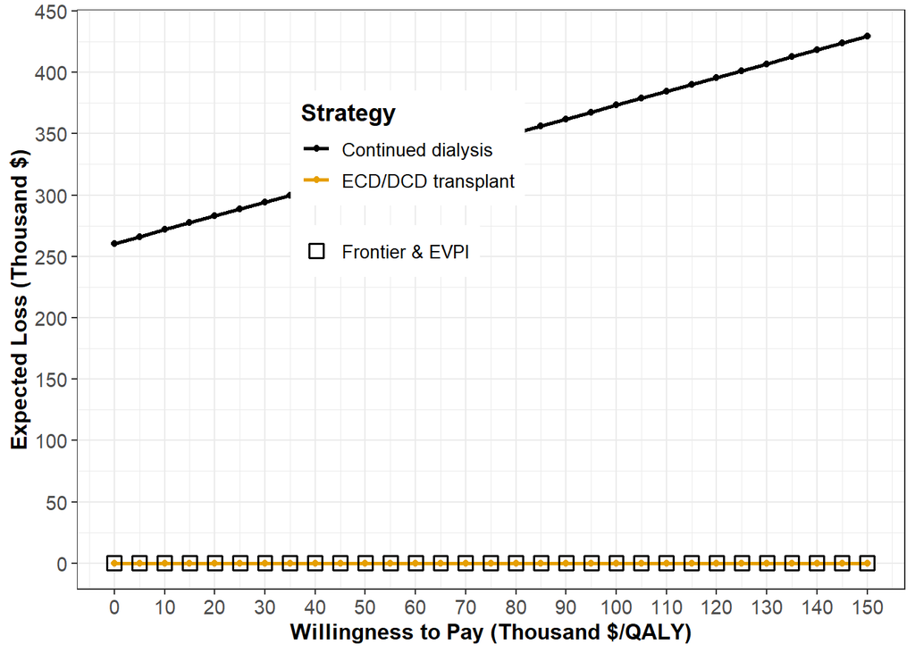

```r
# ELC plot
gg_elc <- plot_exp_loss(elc_obj, log_y = FALSE,
               txtsize = txtsize, xlim = c(0, NA), n_x_ticks = 14,
               col = "full") +
  ggthemes::scale_color_colorblind() +
  ggthemes::scale_fill_colorblind() +
  # geom_point(aes(shape = as.name("Strategy"))) +
  scale_y_continuous("Expected Loss (Thousand $)",
                     breaks = number_ticks(10),
                     labels = function(x) x/1000) +
  theme(legend.position = c(0.4, 0.7),)
gg_elc
```

## 11.3.6 Expected value of perfect information (EVPI)

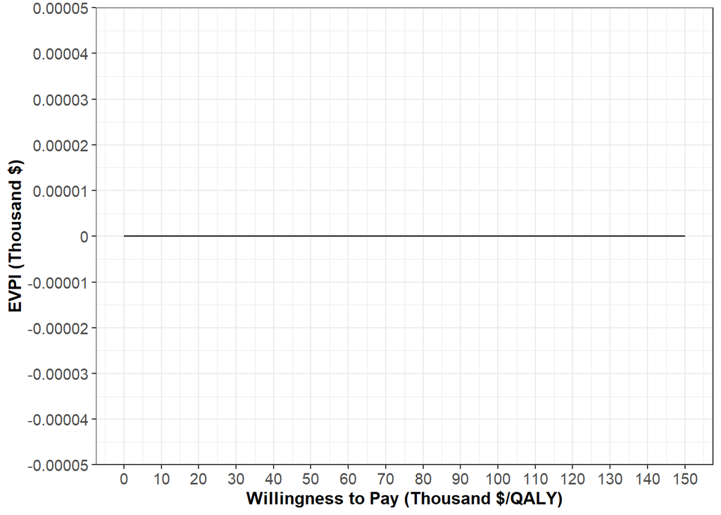

```r
### Expected value of perfect information (EVPI)
evpi <- calc_evpi(wtp = v_wtp, psa = l_psa)
# EVPI plot
gg_evpi <- plot_evpi(evpi, effect_units = "QALY",
                     txtsize = txtsize, xlim = c(0, NA), n_x_ticks = 14) +
  scale_y_continuous("EVPI (Thousand $)",
                     breaks = number_ticks(10),
                     labels = function(x) x/1000)
gg_evpi
```

# 12 Save sensitivity-analysis results (addition to template)

```r
# write.csv(df_ce, file.path(results_dir,"base_case.csv"),row.names=FALSE)
# write.csv(get_sa_spec(l_params_all),file.path(results_dir,"parameter_distributions.csv"),row.names=FALSE)
# write.csv(df_params_owsa,file.path(results_dir,"owsa_ranges.csv"),row.names=FALSE)
# write.csv(df_psa_input,file.path(results_dir,"psa_inputs.csv"),row.names=FALSE)
# write.csv(df_c,file.path(results_dir,"psa_costs.csv"),row.names=FALSE)
# write.csv(df_e,file.path(results_dir,"psa_qalys.csv"),row.names=FALSE)
# write.csv(df_cea_psa,file.path(results_dir,"psa_cea.csv"),row.names=FALSE)
# saveRDS(list(params=l_params_all,owsa=owsa_nmb,twsa=twsa_nmb,twsa_wide=twsa_nmb_wide,
#              psa=l_psa,ceac=ceac_obj,elc=elc_obj,evpi=evpi),
#         file.path(results_dir,"sa_results.rds"))
# ggsave(file.path(results_dir,"psa_scatter.png"),gg_scattter,width=9,height=6)
# ggsave(file.path(results_dir,"ce_plane_incremental.png"),gg_plane,width=9,height=6)
# ggsave(file.path(results_dir,"ceac.png"),gg_ceac,width=9,height=6)
# ggsave(file.path(results_dir,"expected_loss.png"),gg_elc,width=9,height=6)
# ggsave(file.path(results_dir,"evpi.png"),gg_evpi,width=9,height=6)
# ggsave(file.path(results_dir,"tornado.png"),gg_tornado,width=10,height=8)
# write.csv(df_thr_table,file.path(results_dir,"owsa_threshold_table.csv"),row.names=FALSE)
# ggsave(file.path(results_dir,"threshold_horizon.png"),gg_thr_h,width=8,height=5)
# writeLines(capture.output(sessionInfo()),file.path(results_dir,"sessionInfo.txt"))
```

# References

1. Hellemans R, Chesnaye NC, Kramer A, et al. Survival benefit of deceased donor kidney transplantation versus continued dialysis: international target trial emulation. *BMJ*. 2026;394:e100624. doi:10.1136/bmj-2026-100624
2. Leeaphorn N, et al. Deceased donor kidney transplantation versus continued dialysis among patients aged 75 years or older: a target trial emulation. *Am J Kidney Dis*. 2026. doi:10.1053/j.ajkd.2026.02.647 [full author list to be added]
3. Schachtner T, Otto NM, Reinke P. Two decades of the Eurotransplant Senior Program: the gender gap in mortality impacts patient survival after kidney transplantation. *Clin Kidney J*. 2020;13(6):1091-1100. doi:10.1093/ckj/sfz118
4. Vanhove T, Elias N, Safa K, et al. Long-term outcome reporting in older kidney transplant recipients and the limitations of conventional survival metrics. *Kidney Int Rep*. 2022;7(11):2397-2409. doi:10.1016/j.ekir.2022.08.010
5. Ferguson TW, Whitlock RH, Bamforth RJ, et al. Cost-utility of dialysis in Canada: hemodialysis, peritoneal dialysis, and nondialysis treatment of kidney failure. *Kidney Med*. 2021;3(1):20-30.e1. doi:10.1016/j.xkme.2020.07.011
6. Barnieh L, Manns BJ, Klarenbach S, McLaughlin K, Yilmaz S, Hemmelgarn BR. A description of the costs of living and standard criteria deceased donor kidney transplantation. *Am J Transplant*. 2011;11(3):478-488. doi:10.1111/j.1600-6143.2010.03425.x
7. Statistics Canada. Consumer Price Index, annual average, not seasonally adjusted. Table 18-10-0005-01. doi:10.25318/1810000501-eng
8. Wyld M, Morton RL, Hayen A, Howard K, Webster AC. A systematic review and meta-analysis of utility-based quality of life in chronic kidney disease treatments. *PLoS Med*. 2012;9(9):e1001307. doi:10.1371/journal.pmed.1001307
9. CADTH. *Guidelines for the Economic Evaluation of Health Technologies: Canada*. 4th ed. CADTH; 2017.
10. Alarid-Escudero F, Krijkamp EM, Enns EA, et al. A tutorial on time-dependent cohort state-transition models in R using a cost-effectiveness analysis example. *Med Decis Making*. 2023;43(1):21-41. doi:10.1177/0272989X221121747
11. Li B, Cairns JA, Draper H, et al. Estimating health-state utility values in kidney transplant recipients and waiting-list patients using the EQ-5D-5L. *Value Health*. 2017;20(7):976-984. doi:10.1016/j.jval.2017.01.011
12. Laupacis A, Keown P, Pus N, et al. A study of the quality of life and cost-utility of renal transplantation. *Kidney Int*. 1996;50(1):235-242. doi:10.1038/ki.1996.307
13. Perez-Saez MJ, Juega J, Zapatero A, et al. Kidney transplant outcomes in elderly recipients with controlled donation after circulatory death or donation after brain death donors: a registry cohort study. *Transpl Int*. 2021;34(12):2507-2514. doi:10.1111/tri.14141
14. Perez-Saez MJ, Lafuente Covarrubias O, Hernandez D, et al. Early outcomes of kidney transplantation from elderly donors after circulatory death (GEODAS study). *BMC Nephrol*. 2019;20(1):233. doi:10.1186/s12882-019-1412-0
15. **[NEW – ageing]** Statistics Canada. Table 13-10-0114-01. Life expectancy and other elements of the complete life table, three-year estimates, Canada, all provinces except Prince Edward Island (2022/2024, preliminary). Released January 13, 2026. doi:10.25318/1310011401-eng
16. **[NEW]** Summers DM, Watson CJE, Pettigrew GJ, et al. Kidney donation after circulatory death (DCD): state of the art. *Kidney Int*. 2015;88(2):241-249. doi:10.1038/ki.2015.88
17. **[NEW – SA]** de Boer SE, Tegzess E, Kremer D, Bemelman FJ, et al. Comparable outcomes for old, older, and very old deceased donors in old kidney transplant recipients. *Am J Transplant*. 2026;26(5). [pages and DOI to be added]
18. **[NEW – SA]** Bamforth RJ, Beaudry A, Ferguson TW, et al. Costs of assisted home dialysis: a single-payer Canadian model from Manitoba. *Kidney Med*. 2021;3(6):942-950.e1. doi:10.1016/j.xkme.2021.04.019

# Acknowlegdement

For this work we made use of the template developed by the Decision Analysis in R for Technologies in Health (DARTH) workgroup: http://darthworkgroup.com.

The notation of our code is based on the following provided framework and coding convention: Alarid-Escudero, F., Krijkamp, E., Pechlivanoglou, P. et al. A Need for Change! A Coding Framework for Improving Transparency in Decision Modeling. PharmacoEconomics 37, 1329–1339 (2019). https://doi.org/10.1007/s40273-019-00837-x.

- Alarid-Escudero F, Krijkamp EM, Enns EA, Yang A, Hunink MGM Pechlivanoglou P, Jalal H. An Introductory Tutorial on Cohort State-Transition Models in R Using a Cost-Effectiveness Analysis Example. Medical Decision Making, 2023; 43(1). (Epub). https://doi.org/10.1177/0272989X221103163
- Alarid-Escudero F, Krijkamp EM, Enns EA, Yang A, Hunink MGM Pechlivanoglou P, Jalal H. A Tutorial on Time-Dependent Cohort State-Transition Models in R using a Cost-Effectiveness Analysis Example. Medical Decision Making, 2023; 43(1). https://doi.org/10.1177/0272989X221121747

Other work from DARTH can be found on the website: http://darthworkgroup.com/publications/

# Copyright for assignment work

Copyright 2017, THE HOSPITAL FOR SICK CHILDREN AND THE COLLABORATING INSTITUTIONS.All rights reserved in Canada, the United States and worldwide. Copyright, trademarks, trade names and any and all associated intellectual property are exclusively owned by THE HOSPITAL FOR Sick CHILDREN and the collaborating institutions. These materials may be used, reproduced, modified, distributed and adapted with proper attribution.